# Exercise

Relational Data

### Exercise 1

Identify the keys in ggplot2::diamonds

### Exercise 2

Add the location of the origin and destination (i.e. the `lat` and `lon`) to flights.

### Exercise 3

What happened on June 13 2013? Display the spatial pattern of delays, and then use a Google search to cross-reference with the weather.

Note: You may need to install/load **maps** library.

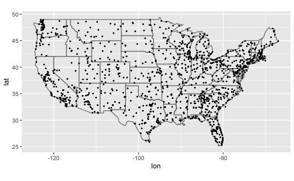

### Exercise 4

What does it mean for a flight to have a missing `tailnum`? What do the tail numbers that don’t have a matching record in planes have in common? (Hint: one variable explains ~90% of the problems.)

### Exercise 5

Filter `flights` to only show those with planes that have flown at least 100 flights.

### Exercise 6

- What does `anti_join(flights, airports, by = c("dest" = "faa"))` tell you?
- What does `anti_join(airports, flights, by = c("faa" = "dest"))` tell you?